# Wiretap BadSpeech Model

Model Performance Report

Wiretap Behavioral Intelligence Team

# Overview

The Wiretap BadSpeech Model categorizes messages by topic and determines their appropriateness of social media messages.The purpose of the model is to provide customers an idea of how inappropriate conversations are on their networks. The model works on individual messages and is platform agnostic; i.e., it doesn’t matter whether the message comes from email or a social media platform, the model can still categorize message by topic. Currently, the model supports English-language messages.

The data for the BadSpeech model come from our data sharing customers (Feedfall Yammer customers). Each message is labeled as one of four categories. At least three independent judgements are used for each message and, when there is considerable disagreement between the labels, more judgements are obtained. The goal of this extensive message labeling process is to produce the best quality data as an input to the Wiretap Natural Language learning models.

Wiretap NLP models, including the BadSpeech model, are developed as Deep Learning Neural Networks and hosted as microservice APIs, making them highly scalable and inexpensive to deploy. Open Source frameworks are used across the microservices stack.

# The Data

**THIS SECTION NOT FOR EXTERNAL CONSUMPTION**

This section describes the data used in the Wiretap BadSpeech Model.

## Acquisition & Labeling

The data for the BadSpeech model are sourced from customer data (Feedfall Yammer customers) and from Twitter.[^1] While Twitter is not usually the best source of enterprise communication data, it does provide a wide variety of language usage. This helps make models derived from these data more robust to changing communication patterns and slang that may appear in a small subset of enterprise messages. Incorporating Twitter data also allows us to create a more balanced dataset. The vast majority of enterprise messages are non offensive. Twitter messages provide a source of offensive and inappropriate messages.

Messages are labeled on the FigureEight (formerly CrowdFlower) platform and MechanicalTurk platform, where human contributors provide labels on a 0-3 scale, where 0 stands for messages not inappropriate for work, while messages and 1, 2, 3 stand for messages inappropriate for a work environment. Specifically, among the offensive messages, 1 stands for the inappropriate category, 2 stands for general harassing (or offensive) category, and 3 stands for discrimination (or hateful) category.

Prior to uploading to FigureEight and MechanicalTurk, each message is passed through RodeoJeans for anonymization.[^2] This includes removing URLs, email addresses, possibly sensitive data (such as phone and social security numbers), as well as replacing person names with randomly generated names. This information is removed to help mitigate any risk associated with releasing customer personal data to outside contractors.

The instructions provided to the FigureEight contributors are included below.

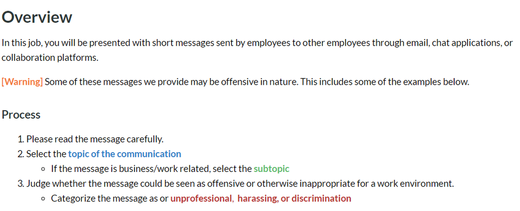

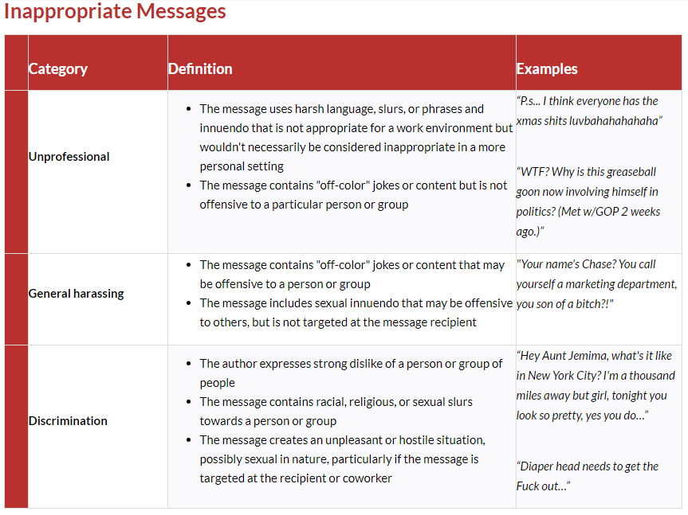

Once labeled, messages are pushed to the LabelStore. All meta data provided by FigureEight, such as the ID for the labeler and a trust metric, is retained in the database. The original, raw message is included in the LabelStore so that the model can be trained off of unmodified data.

## Cleaning & Aggregation

Before modeling, the labeled data are cleaned and aggregated. We use a maximum aggregation rule to construct single labels for each message from the set of the raw labels provided by FigureEight and MechanicalTurk. We compared the majority vote aggregation rule, meaning the label appeared most frequently choosed as the final label with the maximum aggregation rule, meaning the label with the largest number choosed as the final label, and found that the data distribution under maximum strategy are more balanced in each category.

The distribution of labels is provided in the chart below.

[figure not shown]

We can cleary find that appropriate messages are by far the most common in the dataset(67.86%). Unprofesional messages, general harassing and discrimination comprise 8.47%, 11.96% and 11.71% of messages, respectively. While this imbalance reflects reality, more effort should be made in the future to increase the number of labeled messages that are unprofessional, general harassing and discrimination.

## Sampling

There are currently 26404 messages in the dataset. Messages are randomly sampled into three groups corresponding to training, development, and test sets. The breakdown across train, development, and tests sets is provided in the table below.

Sample Breakdown

|  | Size | Share |
| --- | --- | --- |
| train | 19803 | 0.75 |
| development | 5280 | 0.20 |
| test | 1321 | 0.05 |

The sample breakdown used here is fairly typical for machine learning problems, where there is relatively little data. In the future, as the number of available observations increases, the relative portions of the data allocated to the development and test sets will decrease (assuming relative homogeniety of the data).

# The Model

**THIS SECTION NOT FOR EXTERNAL CONSUMPTION**

This section details the design, training, and performance of the model.

## Design

The current neural network uses a design with three major layers.

- **First layer** Language tokens (words, but also emojis and punctuation) are mapped to a vector embedding sourced from *spaCy*.[^3] The vector embedding has more than 600k tokens and is dimension 300. The vector embedding is treated as fixed (i.e., it isn’t trained).
- **Second layer** The vector features from the first layer are used as an input into a standard LSTM layer.[^4] The number of LSTM units is a hyperparameter in the model.
- **Third layer** The outputs from the LSTM layer are passed through a Fully Connected layer, which is transformed with the logit CDF (aka sigmoid function), mapping the output to the $[0, 1]$ interval.

A basic representation of the model’s directed acyclic graph is shown in the below graphic.

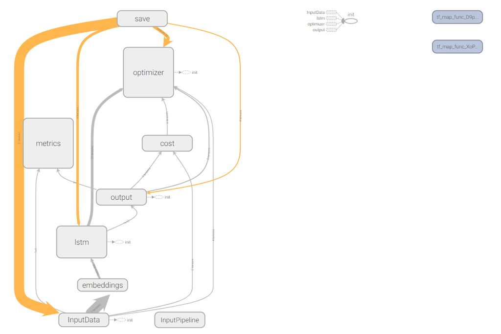

Tunable model parameters in the model include:

- `max_length` The maximum message length to process.
- `lstm_units` The number of LSTM units included in the model.
- `learning_rate` The learning rate for the first epoch during training. This decreases with the square root of the epoch (starting with epoch 3).[^5]

Model training parameters include the following (these are not varried during model training for a particular generation).

- `epochs` The number of training epochs to iterate through the data.
- `batch_size` The batch size for each training iteration.
- `dev_batch_size` The batch size for each metric calculation on the development set.

Training and development batches are shuffled on each epoch, so that the model doesn’t simply learn the order of the data.

The table below shows the current value of the above parameters for the current high-performing model.

| epochs | batch_size | max_length | dev_batch_size | lstm_units | learning_rate |
| --- | --- | --- | --- | --- | --- |
| 20 | 512 | 35 | 512 | 20 | 0.005 |

[figure not shown]

## Cost Function & Evaluation

The model above defines a multiclass classification problem. As such, we use the softmax cross entropy as our loss function and F1 score on each category of message as evaluation metric on the development and test sets.[^6]

Following industry best practice, during training the F1 score on four classes of messages is periodically calculated on a random sample from the development set. Model performance on the development set is used to evaluate different model versions and architectures, with the best-performing model (i.e., the one with the highest F1 score) being selected for production.[^7]

Once a model version is identified, the F1 scores are calculated on the hold-out test data set. This provides an out-of-sample test of model performance in an attempt to more closely mimic real-world performance. For additional validation, other available models are also run on the test set. Currently, this includes the previously deployed version of the Wiretap BadSpeech model. Comparing against the deployed Wiretap model makes it possible to maintain consistency over time as data are added and model architecture evolves.

## Performance

As mentioned above, performance of the model is assessed based on the F1 score on the hold-out test set in order to provide an estimate of the real-world capabilities of the model. Performance is compared to the deployed version of Wiretap BadSpeech model.

The F1 score on other three categories of messages are significantly lower than the nonoffensive messages, and this pattern exists in both deployed and new models. **This indicates we might need some more offensive messages data in enterprise communication context.** We also find that the F1 score of the existing model on classifying the discrimination message is 0. This might be due to too little data size in the hold-out test set, but also indicates that our deployed model is not good at detecting discriminative messages.

[figure not shown]

In order to have a closer look at our model performance, we also compare the precision, recall, balanced-accuracy metrics with the deployed model. We first check the recall rate to see the sensitivity of our model in detecting different categories of messages. We can find that our new model is more sensitive to detecting the offensive messages comparing with the original model.

[figure not shown]

We further check the precision rate of our model. Our new model also advantages the original model in terms of non-offensive messages, harassing messages and discriminative messages but not in inappropriate messages. Again, more data might be needed to improve the proposed model’s performance on inappropriate messages.

[figure not shown]

Finally, we investigate the balanced accuracy rate of our models and found that our new model reaches a level of near 0.70 accuracy(better than our original model) except in terms of inappropriate messages.

[figure not shown]

## Discussion

We clearly find that the new proposed model improves performance on classifying various types of messages on most of the metrics, including F1 scores, recall, precision, and balanced accuracy. Specially, our model also improved significantly in detecting the discriminative messages compared with the old model. But, it still has a large potential to further improve for the following reasons:

- From the ‘Run performance for selected proposed model on inappropriate messages’ and the percentage (8.47%) of the inappropriate message data in the whole training data set, we can conclude that the **inappropriate message data size is too small for our current model to fully capture its characteristics**.
- Currently, we used the *spaCy* as our word embedding. This word embedding is not domain specific to our business context and we expect using the word embeddings that are more closely related to workplace messages will enhance our model performance.

Our next stage of action wil be:

- Try different rules to transform our matrix output to the final classification category. We now used the maximum rules to do classification, meaning we categorized the message based on its largest coefficients on our output matrices.
- Collect more labeled data, especially data on inappropriate messages. These type of data are very hard to define comparing with extreme messages such as harassing and discrimination and common workplace diaglogue.
- Include some externel labeled data sources related to BadSpeech from platform such as Kaggle.[^8]
- Train our new word embedding matrices that are specific to enterprise communication context.
- Experiment with some other neural network models such as CNN to enhance the model performance.[^9]

# Notes & References

[^1]: English messages are randomly sampled from Feedfall data.
[^2]: RodeoJeans is a Python3 library for text processing developed by the Wiretap Behavioral Intelligence Team.
[^3]: [spaCy: Industrial-Strength Natural Language Processing in Python](https://spacy.io/)
[^4]: [Understanding LSTM Networks](http://colah.github.io/posts/2015-08-Understanding-LSTMs/)
[^5]: [Convolutional Neural Networks for Toxic Comment Classification](https://arxiv.org/pdf/1802.09957.pdf)
[^6]: The F1 score is choosed because we want our model to balance between precision and recall, hence has a more robust performance in the future.
[^7]: It’s common for several models to have very similar levels of performance. In this case, secondary metrics — such as computational complexity and categorical predictions — may be used to select the best model. In this case, we consider the performance on all four categories of message data.
[^8]: [Toxic Comment Classification Challenge](http://colah.github.io/posts/2015-08-Understanding-LSTMs/)
[^9]: [Convolutional Neural Networks for Toxic Comment Classification](https://arxiv.org/pdf/1802.09957.pdf)